# TidyDataLab

YG

2023-01-26

# Lab: Nobel laureates

## Getting started

Go to the course GitHub organization and locate the lab repo, which should be named something like `lab-03-nobel-laureates`. Either Fork it or copy it as a template. Then clone it in RStudio. First, open the R Markdown document `lab-03.Rmd` and Knit it. Make sure it compiles without errors. The output will be in the file markdown `.md` file with the same name.

### Warm up

Before we introduce the data, let’s warm up with some simple exercises.

- Update the YAML, changing the author name to your name, and **knit** the document.
- Commit your changes with a meaningful commit message.
- Push your changes to GitHub.
- Go to your repo on GitHub and confirm that your changes are visible in your Rmd **and** md files. If anything is missing, commit and push again.

### Packages

We’ll use the **tidyverse** package for much of the data wrangling. This package is already installed for you. You can load them by running the following in your Console:

```r
library(tidyverse)
```

### Data

The dataset for this assignment can be found as a csv (comma separated values) file in the `data` folder of your repository. You can read it in using the following.

```r
nobel <- read_csv("nobel.csv")
```

The variable descriptions are as follows:

- `id`: ID number
- `firstname`: First name of laureate
- `surname`: Surname
- `year`: Year prize won
- `category`: Category of prize
- `affiliation`: Affiliation of laureate
- `city`: City of laureate in prize year
- `country`: Country of laureate in prize year
- `born_date`: Birth date of laureate
- `died_date`: Death date of laureate
- `gender`: Gender of laureate
- `born_city`: City where laureate was born
- `born_country`: Country where laureate was born
- `born_country_code`: Code of country where laureate was born
- `died_city`: City where laureate died
- `died_country`: Country where laureate died
- `died_country_code`: Code of country where laureate died
- `overall_motivation`: Overall motivation for recognition
- `share`: Number of other winners award is shared with
- `motivation`: Motivation for recognition

In a few cases, the name of the city/country changed after laureate was given (e.g., in 1975, Bosnia and Herzegovina was called the Socialist Federative Republic of Yugoslavia). In these cases the variables below reflect a different name than their counterparts without the suffix `_original`.

- `born_country_original`: Original country where laureate was born
- `born_city_original`: Original city where laureate was born
- `died_country_original`: Original country where laureate died
- `died_city_original`: Original city where laureate died
- `city_original`: Original city where laureate lived at the time of winning the award
- `country_original`: Original country where laureate lived at the time of winning the award

## Exercises

### Get to know your data

1. How many observations and how many variables are in the dataset? Use inline code to answer this question. What does each row represent? There are some observations in this dataset that we will exclude from our analysis to match the Buzzfeed results.

```r
str(nobel)
```

```
## spc_tbl_ [935 × 26] (S3: spec_tbl_df/tbl_df/tbl/data.frame)
##  $ id                   : num [1:935] 1 2 3 4 5 6 6 8 9 10 ...
##  $ firstname            : chr [1:935] "Wilhelm Conrad" "Hendrik A." "Pieter" "Henri" ...
##  $ surname              : chr [1:935] "Röntgen" "Lorentz" "Zeeman" "Becquerel" ...
##  $ year                 : num [1:935] 1901 1902 1902 1903 1903 ...
##  $ category             : chr [1:935] "Physics" "Physics" "Physics" "Physics" ...
##  $ affiliation          : chr [1:935] "Munich University" "Leiden University" "Amsterdam University" "École Polytechnique" ...
##  $ city                 : chr [1:935] "Munich" "Leiden" "Amsterdam" "Paris" ...
##  $ country              : chr [1:935] "Germany" "Netherlands" "Netherlands" "France" ...
##  $ born_date            : Date[1:935], format: "1845-03-27" "1853-07-18" ...
##  $ died_date            : Date[1:935], format: "1923-02-10" "1928-02-04" ...
##  $ gender               : chr [1:935] "male" "male" "male" "male" ...
##  $ born_city            : chr [1:935] "Remscheid" "Arnhem" "Zonnemaire" "Paris" ...
##  $ born_country         : chr [1:935] "Germany" "Netherlands" "Netherlands" "France" ...
##  $ born_country_code    : chr [1:935] "DE" "NL" "NL" "FR" ...
##  $ died_city            : chr [1:935] "Munich" NA "Amsterdam" NA ...
##  $ died_country         : chr [1:935] "Germany" "Netherlands" "Netherlands" "France" ...
##  $ died_country_code    : chr [1:935] "DE" "NL" "NL" "FR" ...
##  $ overall_motivation   : chr [1:935] NA NA NA NA ...
##  $ share                : num [1:935] 1 2 2 2 4 4 1 1 1 1 ...
##  $ motivation           : chr [1:935] "\"in recognition of the extraordinary services he has rendered by the discovery of the remarkable rays subseque"| __truncated__ "\"in recognition of the extraordinary service they rendered by their researches into the influence of magnetism"| __truncated__ "…
##  $ born_country_original: chr [1:935] "Prussia (now Germany)" "the Netherlands" "the Netherlands" "France" ...
##  $ born_city_original   : chr [1:935] "Lennep (now Remscheid)" "Arnhem" "Zonnemaire" "Paris" ...
##  $ died_country_original: chr [1:935] "Germany" "the Netherlands" "the Netherlands" "France" ...
##  $ died_city_original   : chr [1:935] "Munich" NA "Amsterdam" NA ...
##  $ city_original        : chr [1:935] "Munich" "Leiden" "Amsterdam" "Paris" ...
##  $ country_original     : chr [1:935] "Germany" "the Netherlands" "the Netherlands" "France" ...
##  - attr(*, "spec")=
##   .. cols(
##   ..   id = col_double(),
##   ..   firstname = col_character(),
##   ..   surname = col_character(),
##   ..   year = col_double(),
##   ..   category = col_character(),
##   ..   affiliation = col_character(),
##   ..   city = col_character(),
##   ..   country = col_character(),
##   ..   born_date = col_date(format = ""),
##   ..   died_date = col_date(format = ""),
##   ..   gender = col_character(),
##   ..   born_city = col_character(),
##   ..   born_country = col_character(),
##   ..   born_country_code = col_character(),
##   ..   died_city = col_character(),
##   ..   died_country = col_character(),
##   ..   died_country_code = col_character(),
##   ..   overall_motivation = col_character(),
##   ..   share = col_double(),
##   ..   motivation = col_character(),
##   ..   born_country_original = col_character(),
##   ..   born_city_original = col_character(),
##   ..   died_country_original = col_character(),
##   ..   died_city_original = col_character(),
##   ..   city_original = col_character(),
##   ..   country_original = col_character()
##   .. )
##  - attr(*, "problems")=<externalptr>
```

2. Create a new data frame called `nobel_living` that filters for
- laureates for whom `country` is available
- laureates who are people as opposed to organizations (organizations are denoted with `"org"` as their `gender`)
- laureates who are still alive (their `died_date` is `NA`)

Confirm that once you have filtered for these characteristics you are left with a data frame with 228 observations, once again using inline code.

### Most living Nobel laureates were based in the US when they won their prizes

… says the Buzzfeed article. Let’s see if that’s true.

First, we’ll create a new variable to identify whether the laureate was in the US when they won their prize. We’ll use the `mutate()` function for this. The following pipeline mutates the `nobel_living` data frame by adding a new variable called `country_us`. We use an if statement to create this variable. The first argument in the `if_else()` function we’re using to write this if statement is the condition we’re testing for. If `country` is equal to `"USA"`, we set `country_us` to `"USA"`. If not, we set the `country_us` to `"Other"`.

> Note: We can achieve the same result using the `fct_other()` function we’ve seen before (i.e. with `country_us = fct_other(country, "USA")`). We decided to use the `if_else()` here to show you one example of an if statement in R.

```r
nobel_living <- nobel_living %>%
  mutate(
    country_us = if_else(country == "USA", "USA", "Other")
  )
```

Next, we will limit our analysis to only the following categories: Physics, Medicine, Chemistry, and Economics.

> Note: Technically, the Nobel Prize in Economics is a memorial prize. It was established in 1968. If you want to annoy an economist, point that distinction out to them… More info [here](https://en.wikipedia.org/wiki/Nobel_Memorial_Prize_in_Economic_Sciences) if you want to learn some more.

```r
nobel_living_science <- nobel_living %>%
  filter(category %in% c("Physics", "Medicine", "Chemistry", "Economics"))
```

For the next exercise, work with the `nobel_living_science` data frame you created above. You’ll need to define this data frame in your R Markdown document, even though the next exercise doesn’t explicitly ask you to do so.

3. Create a faceted bar plot visualizing the relationship between the category of prize and whether the laureate was in the US when they won the nobel prize. Interpret your visualization, and say a few words about whether the Buzzfeed headline is supported by the data.
   - Your visualization should be faceted by category.
   - For each facet you should have two bars, one for winners in the US and one for Other.
   - Flip the coordinates so the bars are horizontal, not vertical.

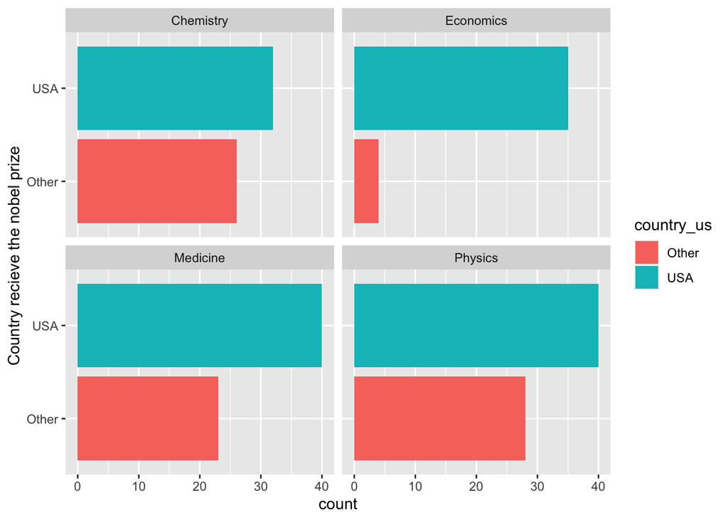

```r
ggplot(nobel_living_science, aes(x=country_us, fill = country_us)) +
  geom_bar() +
  facet_wrap(~category) +
  coord_flip() +
  labs(x="Country recieve the nobel prize ")
```

## But of those US-based Nobel laureates, many were born in other countries

4. Create a new variable called `born_country_us` that has the value `"USA"` if the laureate is born in the US, and `"Other"` otherwise. How many of the winners are born in the US?

```r
nobel %>%
  mutate(born_us = if_else(born_country == "USA", "USA", "Other")) %>%
  count(born_us)
```

```
## # A tibble: 3 × 2
##   born_us     n
##   <chr>   <int>
## 1 Other     636
## 2 USA       271
## 3 <NA>       28
```

5. Add a second variable to your visualization from Exercise 3 based on whether the laureate was born in the US or not. Based on your visualization, do the data appear to support Buzzfeed’s claim? Explain your reasoning in 1-2 sentences.
   - Your final visualization should contain a facet for each category.
   - Within each facet, there should be a bar for whether the laureate won the award in the US or not.
   - Each bar should have segments for whether the laureate was born in the US or not.

```r
n2<- nobel_living_science %>%
  mutate(born_us=ifelse(born_country=="USA", "USA", "Other"))
```

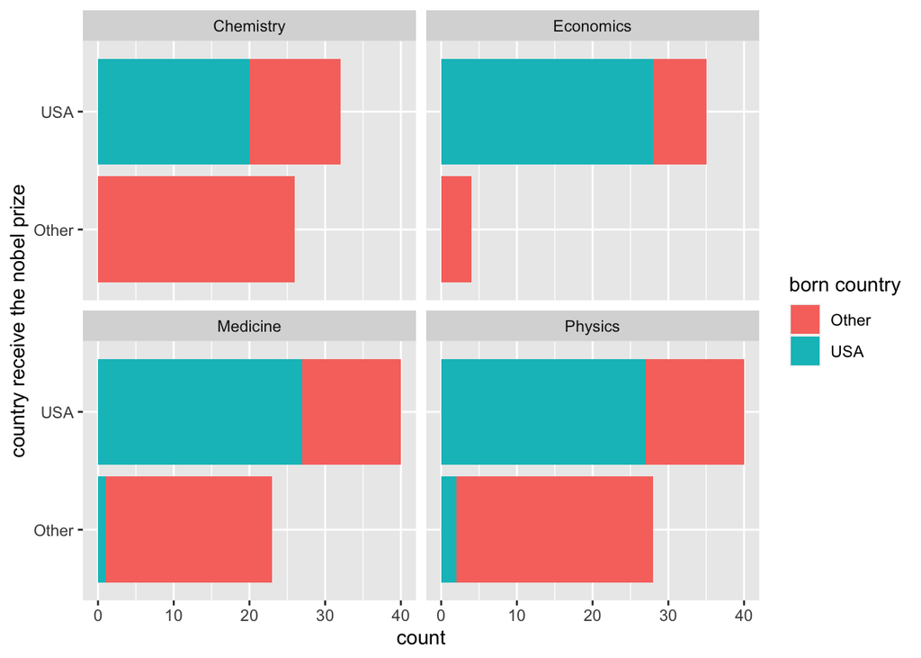

```r
ggplot(n2, aes(x=country_us, fill=born_us)) +
  geom_bar() +
  facet_wrap(~category) +
  coord_flip() +
  labs(x="country receive the nobel prize", fill = "born country")
```

6. In a single pipeline, filter for laureates who won their prize in the US, but were born outside of the US, and then create a frequency table (with the `count()` function) for their birth country (`born_country`) and arrange the resulting data frame in descending order of number of observations for each country. Which country is the most common?

```r
nobel %>%
  filter(country=="USA",
         born_country != "USA") %>%
  count(born_country) %>%
  arrange(desc(n))
```

```
## # A tibble: 37 × 2
##    born_country       n
##    <chr>          <int>
##  1 United Kingdom    15
##  2 Canada            12
##  3 Germany           10
##  4 China              6
##  5 Poland             6
##  6 France             5
##  7 Italy              5
##  8 Japan              5
##  9 Austria            4
## 10 Hungary            4
## # … with 27 more rows
```

## Interested in how Buzzfeed made their visualizations?

The plots in the Buzzfeed article are called waffle plots. You can find the code used for making these plots in Buzzfeed’s GitHub repo (yes, they have one!) [here](https://buzzfeednews.github.io/2017-01-immigration-and-science/). You’re not expected to recreate them as part of your assignment, but you’re welcomed to do so for fun!